# Lab 3B

Tree-based methods and Support Vector Machines

2026

# Getting Started: Loading the Dataset

Before you begin the practical, you need to load the required dataset into R. To ensure a smooth workflow, please follow one of the two options below:

**Option 1: Using a Dedicated Folder**

Create a specific folder for this assignment and place the dataset file inside it. You can then load the data using the `load()` function by specifying the correct file path. (Note for Windows users: Please ensure you change all backslashes `\` in your copied file path to forward slashes `/` in R).

For **Mac** users, your path will look like this:

```r
load("/Users/your_username/Documents/folder_name/dataset_name.RData")
```

For **Windows** users, your path will look like this:

```r
load("C:/Users/your_username/Documents/folder_name/dataset_name.RData")
```

**Option 2: Using an R Project**

Create an R Project (`.Rproj`) for this assignment and store the dataset directly within that project folder. Make sure to open RStudio by double-clicking the `.Rproj` file. This automatically sets your working directory, allowing you to load the dataset directly without a long path:

```r
load("dataset_name.RData")
```

**Note for this specific lab:** Please ensure you have downloaded the tumor.Rdata file from the course environment before proceeding.

In this lab we train models to classify tumors as **benign (B)** or **malignant (M)**.

- **Benign (B):** non-cancerous tumors that do not spread to other tissues.
- **Malignant (M):** cancerous tumors that can grow aggressively and spread.

The dataset `tumor.Rdata` contains 569 observations. The response variable is diagnosis, which indicates whether each tumor is benign or malignant. The dataset also contains 30 numeric features describing characteristics of cell nuclei from tumor samples, such as radius, texture, perimeter, area, smoothness, compactness, concavity and many more.

We will:

- train the models introduced in the lecture on a **training set**
- evaluate their performance on a **test set**
- compare different classifiers.

# Preparation

Before fitting any models, we first load the dataset and inspect its structure.

1. Load the data into the workspace and examine the structure of the dataset.

   **Hint:** Use `load()` to load the data and `str()` to inspect its structure.

**Show Answer**

```r
load("tumor.Rdata")
str(tumor)
```

```
## Classes 'tbl_df', 'tbl' and 'data.frame':    569 obs. of  31 variables:
##  $ diagnosis              : Factor w/ 2 levels "B","M": 2 2 2 2 2 2 2 2 2 2 ...
##  $ radius_mean            : num  18 20.6 19.7 11.4 20.3 ...
##  $ texture_mean           : num  10.4 17.8 21.2 20.4 14.3 ...
##  $ perimeter_mean         : num  122.8 132.9 130 77.6 135.1 ...
##  $ area_mean              : num  1001 1326 1203 386 1297 ...
##  $ smoothness_mean        : num  0.1184 0.0847 0.1096 0.1425 0.1003 ...
##  $ compactness_mean       : num  0.2776 0.0786 0.1599 0.2839 0.1328 ...
##  $ concavity_mean         : num  0.3001 0.0869 0.1974 0.2414 0.198 ...
##  $ concave_points_mean    : num  0.1471 0.0702 0.1279 0.1052 0.1043 ...
##  $ symmetry_mean          : num  0.242 0.181 0.207 0.26 0.181 ...
##  $ fractal_dimension_mean : num  0.0787 0.0567 0.06 0.0974 0.0588 ...
##  $ radius_se              : num  1.095 0.543 0.746 0.496 0.757 ...
##  $ texture_se             : num  0.905 0.734 0.787 1.156 0.781 ...
##  $ perimeter_se           : num  8.59 3.4 4.58 3.44 5.44 ...
```

[output cut: 17 more lines]

```r
# colnames(tumor) # see the name of the variables
```

**Question:** How many observations and variables does the dataset contain? Which variable is the response variable?

2. Load the packages needed for this practical.

   We will use packages for tree-based methods, Support Vector Machines, model evaluation, and data handling.

   **Hint:** Use `library()` to load the required packages.

**Show Answer**

```r
library(tree)
library(randomForest)
library(xgboost)
library(e1071)
library(caret)
library(dplyr)
library(ggplot2)
```

3. We will use **75% of the observations** as the training set and the remaining **25%** as the test set. Create a vector containing the row indices of the observations that will be used for training. Use `sample()` and set the seed to `1` for reproducibility.

   **Hint:** Use `set.seed()` before `sample()`. The function `nrow(tumor)` gives the number of observations in the dataset.

**Show Answer**

```r
# Setting a seed ensures the random train/test split is identical every time the code runs
set.seed(1)

# Randomly select 75% of the observations for the training set
train <- sample(1:nrow(tumor), size = 0.75 * nrow(tumor))
```

# Model training

In this section, we train the classifiers on the **training set**. We also create plots that help us understand how these classifiers work.

The models are fitted using only the training observations selected in the previous section. Later, we will evaluate the fitted models on the test set.

## Pruned tree

A decision tree can easily **overfit** the training data if it grows too large. This means that the tree may fit the training data very well, but perform worse on new data.

**Pruning** reduces the size of the tree by removing splits that do not improve predictive performance. In this practical, we use **cross-validation** to choose an appropriate tree size.

1. Obtain a pruned tree for the training set. Save the object as `tumor_prune`, and plot it.

   **Hint:** Use `tree()` to grow the initial tree, `cv.tree()` to find the optimal size via cross-validation, and `prune.tree()` to cut it back.

**Show Answer**

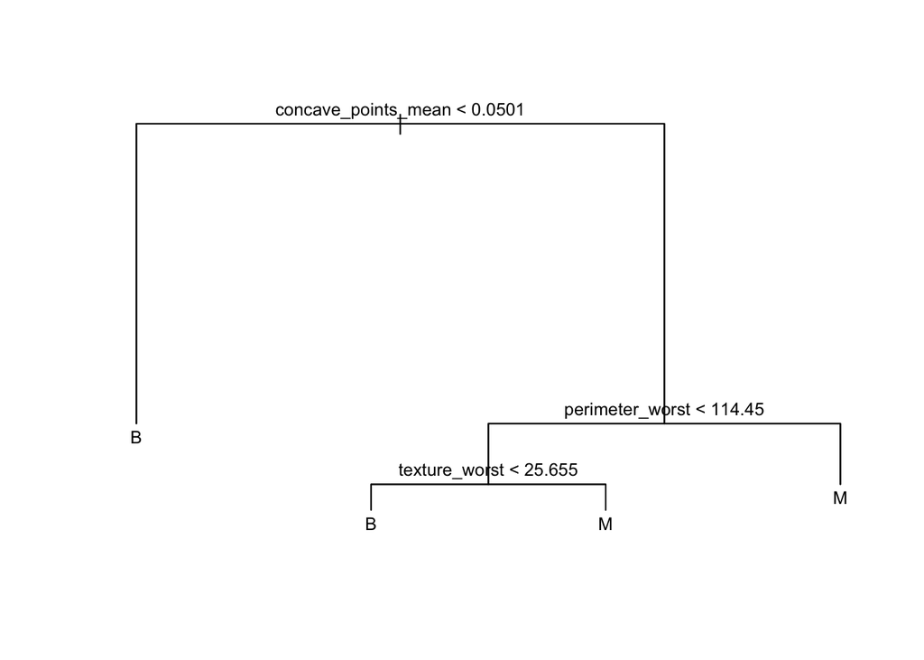

```r
# make a tree object that is, Fit a classification tree on the training data
tumor_tree  <- tree(diagnosis ~ ., data = tumor[train, ])
# or this tumor_tree <- tree(diagnosis ~ ., data = tumor, subset = train)
# Perform cross-validation to select tree size
cv_tumor    <- cv.tree(tumor_tree)

# Select the tree with the lowest cross-validated deviance
tumor_prune <- prune.tree(tumor_tree, best = cv_tumor$size[which.min(cv_tumor$dev)])

## or This chooses the tree size with the lowest cross-validated classification error.
# cv_tumor <- cv.tree(tumor_tree, FUN = prune.misclass)
# tumor_prune <- prune.misclass(tumor_tree, best = cv_tumor$size[which.min(cv_tumor$dev)])

# plot the pruned tree
plot(tumor_prune)
text(tumor_prune, cex = 0.8)
```

## Bagging and Random Forest

Single decision trees often have **high variance**, meaning their predictions can change a lot with small changes in the data.

**Bagging (bootstrap aggregating)** reduces variance by training many trees on **bootstrap samples** of the training data. For classification problems, the trees are combined using a **majority vote**.

**Random forests** further improve this idea by using a **random subset of predictors at each split**. This makes the trees less correlated and can improve predictive performance.

1. Train the **bagging** model `tumor_bag` and the **random forest** model `tumor_rf` on the training set. Display the output of both models. Set the seed to `1` for reproducibility.

   **Hint:** Bagging uses **all predictors at each split**, so set `mtry` equal to the number of predictors. Random forests use a **random subset of predictors** at each split. Use `randomForest()`. The default `mtry` for classification in `randomForest()` is `floor(sqrt(p))`. Since there are 30 predictors, the default is 5.

**Show Answer**

```r
set.seed(1)

# Bagging: use all 30 predictors at each split
tumor_bag <- randomForest(
  diagnosis ~ .,
  data = tumor[train, ],
  importance = TRUE,
  mtry = 30,
  ntree = 250
)

tumor_bag
```

```
##
## Call:
##  randomForest(formula = diagnosis ~ ., data = tumor[train, ],      importance = TRUE, mtry = 30, ntree = 250)
##                Type of random forest: classification
##                      Number of trees: 250
## No. of variables tried at each split: 30
##
##         OOB estimate of  error rate: 3.52%
## Confusion matrix:
##     B   M class.error
## B 266   5  0.01845018
## M  10 145  0.06451613
```

```r
set.seed(1)

# Random forest: for classification, the default mtry is floor(sqrt(p))
tumor_rf <- randomForest(
  diagnosis ~ .,
  data = tumor[train, ],
  importance = TRUE,
  ntree = 250
)

tumor_rf
```

```
##
## Call:
##  randomForest(formula = diagnosis ~ ., data = tumor[train, ],      importance = TRUE, ntree = 250)
##                Type of random forest: classification
##                      Number of trees: 250
## No. of variables tried at each split: 5
##
##         OOB estimate of  error rate: 3.76%
## Confusion matrix:
##     B   M class.error
## B 268   3  0.01107011
## M  13 142  0.08387097
```

2. Display the **variable importance plots** of both `tumor_bag` and `tumor_rf` for the 10 most important predictors. Use `type = 1` to display importance based on prediction accuracy. Compare the two plots.

   The importance measure shows how much the **prediction accuracy decreases when a variable is permuted**. Variables that cause a larger decrease in accuracy are considered **more important** for the model.

   **Hint:** Use `varImpPlot()`. The argument `n.var = 10` displays the 10 most important predictors, and `type = 1` uses the mean decrease in accuracy.*

**Show Answer**

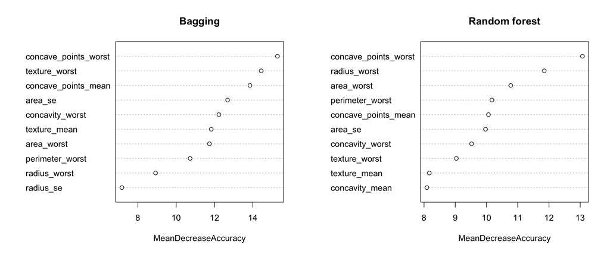

```r
# Comparing variable importance side-by-side reveals which features consistently drive classification accuracy
par(mfrow = c(1, 2))

varImpPlot(
  tumor_bag,
  n.var = 10,
  type = 1,
  main = "Bagging"
)

varImpPlot(
  tumor_rf,
  n.var = 10,
  type = 1,
  main = "Random forest"
)
```

```r
par(mfrow = c(1, 1))
```

## Boosting

The previous models used either one tree or many independent trees. **Boosting** is another ensemble method, but it works differently from bagging and random forests.

Boosting builds trees **sequentially**. Each new tree tries to improve the mistakes made by the previous trees. The final prediction is obtained by combining many small trees, which often improves predictive accuracy.

In this practical, we use the `xgboost` package to fit a boosted tree model.

### Preparing the data for XGBoost

1. Prepare the training data for `xgboost`.

   The `xgboost` package requires the predictors to be stored in a numeric matrix and the response variable to be coded as `0` and `1`.

   Use the training observations only. Convert `diagnosis` into a binary response, where:
- `0` means benign;
- `1` means malignant.

  Then use `model.matrix()` to create a numeric matrix of predictors and use `xgb.DMatrix()` to create the training object.

  **Hint:** Use `tumor[train, ]` to select the training data. Use `ifelse()` to convert `diagnosis` into 0/1 values. Use `model.matrix(diagnosis ~ . - 1, data = tumor_train)` to create the predictor matrix.

**Show Answer**

```r
# Training data
tumor_train <- tumor[train, ]

# Make sure diagnosis is a factor
tumor_train$diagnosis <- as.factor(tumor_train$diagnosis)

# Convert the response variable to 0/1
# Benign = 0, Malignant = 1
y <- ifelse(tumor_train$diagnosis == "M", 1, 0)

# Convert predictors to a numeric matrix
x <- model.matrix(diagnosis ~ . - 1, data = tumor_train)

## Create the XGBoost training matrix. That is, XGBoost training object,
## which stores the predictors and labels

dtrain <- xgb.DMatrix(data = x, label = y)
```

### Tuning the XGBoost model

2. Use 5-fold cross-validation to compare several XGBoost tuning combinations.

   We vary the following hyperparameters:
- `eta`: the learning rate. It controls how strongly each new tree contributes to the model. Smaller values make learning slower but can sometimes improve generalization.
- `max_depth`: the maximum depth of each tree;
- `colsample_bytree`: the proportion of predictors sampled for each tree;
- `subsample`: the proportion of observations sampled for each tree.

  We also set:
- `gamma = 0`: it says allow a split if it gives any improvement. No extra restriction is added for making a split. Larger values make the model more conservative.
- `min_child_weight = 1`: the default value. Larger values make it harder to create very small leaves and can reduce overfitting to some extent.

  Use classification error as the evaluation metric. Then calculate accuracy as `1 - error`.

  **Hint:** Use `expand.grid()` to create a data frame containing all combinations of the tuning parameter values. Each row of this **grid** is one combination of hyperparameter values that will be tested. Then use `createFolds(tumor_train$diagnosis, k = 5, returnTrain = FALSE)` to create the same 5 test folds for all tuning combinations. Inside the `for` loop, take one row of the grid at a time, put those values into a list called `xgb_params`, and pass them to `xgb.cv()`. The output `cv$evaluation_log` contains the cross-validation error for each boosting round. Use `which.min(eval_log$test_error_mean)` to find the boosting round with the lowest cross-validated error. Store the error and calculate accuracy using `1 - error`.

**Show Answer**

```r
dtrain <- xgb.DMatrix(data = x, label = y)
# Grid search over learning rate, tree depth, and stochastic sampling parameters
xgb_grid <- expand.grid(
  eta = c(0.3, 0.4),
  max_depth = c(1, 2, 3),
  gamma = 0,
  colsample_bytree = c(0.6, 0.8),
  min_child_weight = 1,
  subsample = c(0.5, 0.75, 1.0),
  nrounds = 100
)

# Create the same 5 folds for all tuning combinations
set.seed(1)
folds <- createFolds(tumor_train$diagnosis, k = 5, returnTrain = FALSE)

# Store cross-validation results
cv_results <- list()

for (i in seq_len(nrow(xgb_grid))) {

  # Define parameters for this tuning combination
  xgb_params <- list(
    objective = "binary:logistic",
    eval_metric = "error",
    eta = xgb_grid$eta[i],
    max_depth = xgb_grid$max_depth[i],
    gamma = xgb_grid$gamma[i],
    colsample_bytree = xgb_grid$colsample_bytree[i],
    min_child_weight = xgb_grid$min_child_weight[i],
    subsample = xgb_grid$subsample[i],
    seed = 1,
    verbosity = 0
  )

  # 5-fold cross-validation
  cv <- xgb.cv(
    params = xgb_params,
    data = dtrain,
    nrounds = xgb_grid$nrounds[i],
    folds = folds,
    verbose = 0
  )

  # Extract cross-validation results
  eval_log <- cv$evaluation_log

  # Select the number of boosting rounds with the lowest test error
  best_idx <- which.min(eval_log$test_error_mean)

  # Save the results
  cv_results[[i]] <- data.frame(
    eta = xgb_grid$eta[i],
    max_depth = xgb_grid$max_depth[i],
    gamma = xgb_grid$gamma[i],
    colsample_bytree = xgb_grid$colsample_bytree[i],
    min_child_weight = xgb_grid$min_child_weight[i],
    subsample = xgb_grid$subsample[i],
    best_iteration = eval_log$iter[best_idx],
    error = eval_log$test_error_mean[best_idx],
    accuracy = 1 - eval_log$test_error_mean[best_idx]
  )
}

# Combine all cross-validation results
xgb_tuning_results <- bind_rows(cv_results)

# Display the tuning results
xgb_tuning_results
```

```
##    eta max_depth gamma colsample_bytree min_child_weight subsample
## 1  0.3         1     0              0.6                1      0.50
## 2  0.4         1     0              0.6                1      0.50
## 3  0.3         2     0              0.6                1      0.50
## 4  0.4         2     0              0.6                1      0.50
## 5  0.3         3     0              0.6                1      0.50
## 6  0.4         3     0              0.6                1      0.50
## 7  0.3         1     0              0.8                1      0.50
## 8  0.4         1     0              0.8                1      0.50
## 9  0.3         2     0              0.8                1      0.50
## 10 0.4         2     0              0.8                1      0.50
## 11 0.3         3     0              0.8                1      0.50
## 12 0.4         3     0              0.8                1      0.50
## 13 0.3         1     0              0.6                1      0.75
## 14 0.4         1     0              0.6                1      0.75
```

[output cut: 59 more lines]

### Fitting the final XGBoost model

3. Select the tuning combination with the highest cross-validated accuracy. Then fit the final boosted tree model and save it as `tumor_xgb`.

   **Hint:** The object `xgb_tuning_results` contains one row for each tuning combination tested in cross-validation. First, sort this table by `accuracy` from highest to lowest using `arrange(desc(accuracy))`. Then use `slice(1)` to keep only the best row and save it as `best_params_row`. The values in `best_params_row` are used to define the final `XGBoost` parameters. Finally, use `xgb.train()` to fit the final model on the full training data `dtrain`. Use `best_params_row$best_iteration` as the value of `nrounds`, because this is the number of boosting rounds that gave the lowest cross-validated error.

**Show Answer**

```r
dtrain <- xgb.DMatrix(data = x, label = y)
# Select the tuning combination with the highest accuracy
best_params_row <- xgb_tuning_results %>%
  arrange(desc(accuracy)) %>%
  slice(1)

best_params_row
```

```
##   eta max_depth gamma colsample_bytree min_child_weight subsample
## 1 0.4         3     0              0.8                1         1
##   best_iteration      error  accuracy
## 1             67 0.02344733 0.9765527
```

```r
# Define the final model parameters
final_params <- list(
  objective = "binary:logistic",
  eval_metric = "error",
  eta = best_params_row$eta,
  max_depth = best_params_row$max_depth,
  gamma = best_params_row$gamma,
  colsample_bytree = best_params_row$colsample_bytree,
  min_child_weight = best_params_row$min_child_weight,
  subsample = best_params_row$subsample,
  seed = 1,
  verbosity = 0
)

# Fit the final XGBoost model
tumor_xgb <- xgb.train(
  params = final_params,
  data = dtrain,
  nrounds = best_params_row$best_iteration,
  verbose = 0
)

tumor_xgb
```

```
## ##### xgb.Booster
## call:
##   xgb.train(params = final_params, data = dtrain, nrounds = best_params_row$best_iteration,
##     verbose = 0)
## # of features: 30
## # of rounds:  67
```

The object `tumor_xgb` is the final fitted boosted tree model.It has learned patterns from the training data and can later be used to predict whether tumors in the test set are benign or malignant. The model uses **30 features**, corresponding to the 30 numeric predictors in the tumor dataset.The model was trained for **67 boosting rounds**. This number was selected from cross-validation as the number of rounds with the lowest cross-validated classification error.

4. Plot the cross-validation results to examine how the tuning parameters affect model performance. The plot shows the cross-validated accuracy for different combinations of `max_depth`, `eta`, `subsample`, and `colsample_bytree`. Higher accuracy indicates better performance.

   **Hint:** Use `ggplot()` with `max_depth` on the x-axis and `accuracy` on the y-axis. Use different colors for different values of `eta`, and use facets to compare different values of `subsample` and `colsample_bytree`. Note that `colsample_bytree` the proportion of predictors randomly selected when building each tree. Smaller values make the trees more different from each other and may help reduce overfitting.

**Show Answer**

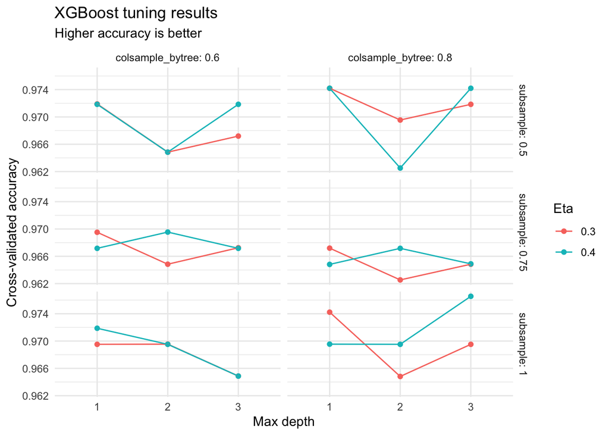

```r
# Visualizing the hyperparameter landscape helps confirm if the model is stable across different settings
ggplot(
  xgb_tuning_results,
  aes(
    x = factor(max_depth),
    y = accuracy,
    color = factor(eta),
    group = factor(eta)
  )
) +
  geom_point() +
  geom_line() +
  facet_grid(
    subsample ~ colsample_bytree,
    labeller = label_both
  ) +
  labs(
    x = "Max depth",
    y = "Cross-validated accuracy",
    color = "Eta",
    title = "XGBoost tuning results",
    subtitle = "Higher accuracy is better"
  ) +
  theme_minimal()
```

**Question:** Which combination of tuning parameters gives the highest cross-validated accuracy?

**Question:** Does increasing `max_depth` always improve the cross-validated accuracy? What does this tell us about model complexity?

The plot shows the cross-validated accuracy for different XGBoost tuning combinations.

So, all tuning combinations perform well, with cross-validated accuracy roughly between 0.962 and 0.977. This means that XGBoost is relatively stable on this dataset: changing the tuning parameters changes the accuracy only slightly.

The best-performing model has `eta = 0.4`, `max_depth = 3`, `colsample_bytree = 0.8`, and `subsample = 1`. This model has a cross-validated accuracy of approximately 0.977.

There is no clear pattern showing that larger `max_depth` always improves performance. In some cases, deeper trees perform better, but in other cases they perform worse. This shows that increasing model complexity does not always improve predictive performance.

The effect of `eta` also depends on the other tuning parameters. Sometimes `eta = 0.4` performs better, while in other settings `eta = 0.3` performs similarly or only slightly worse.

The plot suggests that the XGBoost model performs well, but the exact choice of tuning parameters has only a small effect on cross-validated accuracy. We will still evaluate the final model on the test set before making a final conclusion.

5. Identify the tuning combination with the highest cross-validated accuracy.

   Report the values of `eta`, `max_depth`, `colsample_bytree`, `subsample`, `best_iteration`, and the corresponding cross-validated accuracy. Does this result align with what you observed in the previous plot?

   Note that in this code `arrange(desc(accuracy))` sorts the results from highest to lowest accuracy. Then `slice(1)` keeps only the best row.

   **Hint:** `arrange(desc(accuracy))` sorts the results from highest to lowest accuracy, and `slice(1)` keeps only the top row.

**Show Answer**

```r
# Isolating the absolute best-performing configuration
xgb_tuning_results %>%
  arrange(desc(accuracy)) %>%
  slice(1)
```

```
##   eta max_depth gamma colsample_bytree min_child_weight subsample
## 1 0.4         3     0              0.8                1         1
##   best_iteration      error  accuracy
## 1             67 0.02344733 0.9765527
```

**Question:** Which tuning combination gives the highest cross-validated accuracy? What is the value of that accuracy?

6. Display the variable importance plot for the final XGBoost model.

   As you know, variable importance helps us understand which predictors were most useful for the XGBoost model. In `xgboost`, the default importance measure is **Gain**, which shows how much each variable contributed to improving the model when it was used in a split.

   **Hint:** First use `xgb.importance()` to calculate the importance values. The argument `feature_names = colnames(x)` gives the predictor names, and `model = tumor_xgb` tells R to use the final fitted XGBoost model. Then use `xgb.plot.importance()` to plot the most important predictors. The argument `top_n = 20` shows only the 20 most important variables, which makes the plot easier to read.

**Show Answer**

```r
# Gain measures the improvement in accuracy brought by a feature to the branches it is on.
importance_matrix <- xgb.importance(
  feature_names = colnames(x),
  model = tumor_xgb
)

importance_matrix
```

```
##                     Feature         Gain       Cover Frequency
##                      <char>        <num>       <num>     <num>
##  1:     concave_points_mean 0.5059808724 0.127878938   0.06875
##  2:    concave_points_worst 0.1808629591 0.122546611   0.05625
##  3:         perimeter_worst 0.0726886937 0.078964516   0.03750
##  4:           texture_worst 0.0659426967 0.120014572   0.13125
##  5:              area_worst 0.0318234854 0.080918672   0.07500
##  6:            radius_worst 0.0226987374 0.075907427   0.02500
##  7:         concavity_worst 0.0225606683 0.041365256   0.04375
##  8:            texture_mean 0.0162855046 0.026468583   0.05625
##  9:               area_mean 0.0161571987 0.036220542   0.01250
## 10:        smoothness_worst 0.0104616566 0.016535689   0.04375
## 11:               radius_se 0.0093395597 0.048142075   0.03125
## 12:                 area_se 0.0088127963 0.048051225   0.05625
## 13:          compactness_se 0.0074488863 0.027786529   0.06875
```

[output cut: 16 more lines]

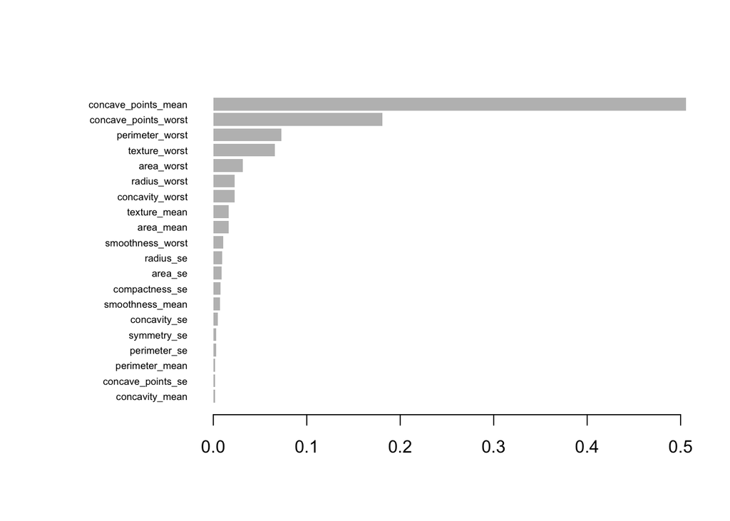

```r
xgb.plot.importance(
  importance_matrix = importance_matrix,
  top_n = 20
)
```

**Question:** Which predictors are most important in the final XGBoost model? Are they similar to the important predictors found for bagging and random forest?

The variable importance plot shows which predictors contributed most to the final XGBoost model.

The most important predictor is `concave_points_mean`. It has a much larger importance value than all other predictors, meaning that it contributed the most to improving the model’s classification performance. The next most important predictors are `concave_points_worst`, `perimeter_worst`, and `texture_worst`. These variables also helped the model distinguish between benign and malignant tumors, but their importance is much smaller than that of `concave_points_mean`. Most of the remaining variables have relatively low importance. This suggests that the XGBoost model relies mainly on a small number of highly informative predictors.

So, the plot suggests that variables related to concave points, perimeter, texture, area, and radius are especially useful for classifying tumors as benign or malignant.

## Support Vector Machines (SVM)

As we learned in the lecture, **SVMs** classify observations by finding a boundary that separates the classes as well as possible.

With a **linear kernel**, the decision boundary is linear. With a **radial kernel**, the decision boundary can be **nonlinear**, allowing the model to capture more complex patterns in the data.

SVMs are sensitive to the scale of the predictors. Therefore, the predictors should be scaled before fitting the model. The function `tune.svm()` scales the predictors by default.

1. Train an SVM model with a **radial kernel** on the training set. Tune the cost parameter and save the result as `tumor_svm_radial`. Then train an SVM model with a **linear kernel** using the same cost values and save the result as `tumor_svm_linear`.

   **Hint:** Use `tune.svm()`. The argument `kernel = "radial"` fits a nonlinear SVM, while `kernel = "linear"` fits a linear SVM. The argument `cost` controls the penalty for classification mistakes.

**Show Answer**

```r
set.seed(1)

# Tuning the radial kernel SVM: finding the optimal cost (C) parameter to balance margin width and training errors
tumor_svm_radial <- tune.svm(
  diagnosis ~ .,
  data = tumor[train, ],
  kernel = "radial",
  cost = c(0.5, 1, 1.5),
  tunecontrol = tune.control(cross = 5)
)

tumor_svm_radial
```

```
##
## Parameter tuning of 'svm':
##
## - sampling method: 5-fold cross validation
##
## - best parameters:
##  cost
##   1.5
##
## - best performance: 0.02350205
```

```r
set.seed(1)

# Tuning the linear kernel SVM: assessing if a simple straight hyper-plane is sufficient
tumor_svm_linear <- tune.svm(
  diagnosis ~ .,
  data = tumor[train, ],
  kernel = "linear",
  cost = c(0.5, 1, 1.5),
  tunecontrol = tune.control(cross = 5)
)

tumor_svm_linear
```

```
##
## Parameter tuning of 'svm':
##
## - sampling method: 5-fold cross validation
##
## - best parameters:
##  cost
##   0.5
##
## - best performance: 0.02112175
```

The tuning output shows the best value of `cost` for each SVM model and the corresponding cross-validation error.

For the linear SVM, the best value is `cost = 0.5`, with a cross-validation error of approximately `0.021`.

Since the linear SVM has the lower cross-validation error, it performs slightly better than the radial SVM on the training data during cross-validation.

The difference between the two errors is small, so both kernels perform well.

However, based on cross-validation, the linear kernel is preferred here.

Note that The tuning parameter `cost` controls the trade-off between allowing classification errors and fitting the training data closely. - A smaller `cost` allows more training errors and usually gives a simpler model. - A larger `cost` penalizes training errors more strongly and may give a more complex model. We tune `cost` to find the value that gives the lowest cross-validation error.

**Question:** Which kernel gives the lower cross-validation error: the radial kernel or the linear kernel?

# Testing the models

In this section, we evaluate the fitted models on the **test set**. The test set contains the observations that were not used for training.

1. Save the class predictions of all fitted models on the test set.

   **Hint:** Use `tumor[-train, ]` to select the test observations. For most models, use `predict()` directly. For XGBoost, first create the test predictor matrix in the same format as the training predictor matrix.

**Show Answer**

```r
# Test data
tumor_test <- tumor[-train, ]

# Pruned tree predictions
prune <- predict(
  tumor_prune,
  newdata = tumor_test,
  type = "class"
)

# Bagging predictions
bag <- predict(
  tumor_bag,
  newdata = tumor_test
)

# Random forest predictions
rf <- predict(
  tumor_rf,
  newdata = tumor_test
)

# XGBoost needs the test predictors in the same model.matrix format as training
test_x <- model.matrix(diagnosis ~ . - 1, data = tumor_test)
test_x <- test_x[, colnames(x), drop = FALSE]

# Predicted probabilities for the malignant class
boost_prob <- predict(tumor_xgb, test_x)

# Convert probabilities to class labels
boost <- ifelse(
  boost_prob > 0.5,
  "M",
  "B"
)

boost <- factor(boost, levels = levels(tumor$diagnosis))

# Radial SVM predictions
svm_radial <- predict(
  tumor_svm_radial$best.model,
  newdata = tumor_test
)

# Linear SVM predictions
svm_linear <- predict(
  tumor_svm_linear$best.model,
  newdata = tumor_test
)
```

2. Display the confusion matrix for each model.

   As we discussed this in the lecture, a confusion matrix compares the **true class labels** with the **predicted class labels**. It helps us see how many tumors were classified correctly and how many were misclassified.

   **Hint:** The true test labels are stored in `tumor_test$diagnosis`. Use `table()` to compare the observed labels with the predicted labels.

**Show Answer**

```r
# Function to create a confusion matrix
cf <- function(est) {
  table(
    observed = tumor_test$diagnosis,
    predicted = est
  )
}

cat("Pruned tree\n")
```

```
## Pruned tree
```

```r
cf(prune)
```

```
##         predicted
## observed  B  M
##        B 85  1
##        M 11 46
```

```r
cat("\nBagging\n")
```

```
##
## Bagging
```

```r
cf(bag)
```

```
##         predicted
## observed  B  M
##        B 85  1
##        M  8 49
```

```r
cat("\nRandom forest\n")
```

```
##
## Random forest
```

```r
cf(rf)
```

```
##         predicted
## observed  B  M
##        B 85  1
##        M  7 50
```

```r
cat("\nBoosting\n")
```

```
##
## Boosting
```

```r
cf(boost)
```

```
##         predicted
## observed  B  M
##        B 85  1
##        M  4 53
```

```r
cat("\nSVM radial\n")
```

```
##
## SVM radial
```

```r
cf(svm_radial)
```

```
##         predicted
## observed  B  M
##        B 86  0
##        M  3 54
```

```r
cat("\nSVM linear\n")
```

```
##
## SVM linear
```

```r
cf(svm_linear)
```

```
##         predicted
## observed  B  M
##        B 84  2
##        M  3 54
```

3. Based on the confusion matrices, compare the performance of the models on the test set. So, calculate the test accuracy for each model and identify the best-performing model based on the test accuracy.

   **Hint:** Accuracy is the proportion of test observations that were classified correctly. Use `mean(predicted == observed)` to calculate it.

**Show Answer**

```r
# True class labels in the test set
observed <- tumor_test$diagnosis

# Calculate test accuracy for each model
model_accuracy <- data.frame(
  model = c(
    "Pruned tree",
    "Bagging",
    "Random forest",
    "Boosting",
    "SVM radial",
    "SVM linear"
  ),
  accuracy = c(
    mean(prune == observed),
    mean(bag == observed),
    mean(rf == observed),
    mean(boost == observed),
    mean(svm_radial == observed),
    mean(svm_linear == observed)
  )
)

# Display accuracies
model_accuracy
```

```
##           model  accuracy
## 1   Pruned tree 0.9160839
## 2       Bagging 0.9370629
## 3 Random forest 0.9440559
## 4      Boosting 0.9650350
## 5    SVM radial 0.9790210
## 6    SVM linear 0.9650350
```

```r
# Identify the best model
best_test_model <- model_accuracy %>%
  arrange(desc(accuracy)) %>%
  slice(1)

best_test_model
```

```
##        model accuracy
## 1 SVM radial 0.979021
```

**Question:** Which model has the highest test accuracy? Is this the same model that performed best during cross-validation?

# Advanced exercise

1. Display boxplots of the standardized features and of the standardized logarithms of the features.

   This exercise helps us see how the distributions of the predictors change after applying a logarithmic transformation. The logarithmic transformation can reduce the effect of very large values and make skewed variables look more symmetric.

   **Hint:** Use `tumor[, -1]` to remove the response variable `diagnosis`. Use `scale()` to standardize the predictors so that they have mean 0 and standard deviation 1. Use `log()` before `scale()` to standardize the logarithms of the predictors.

**Show Answer**

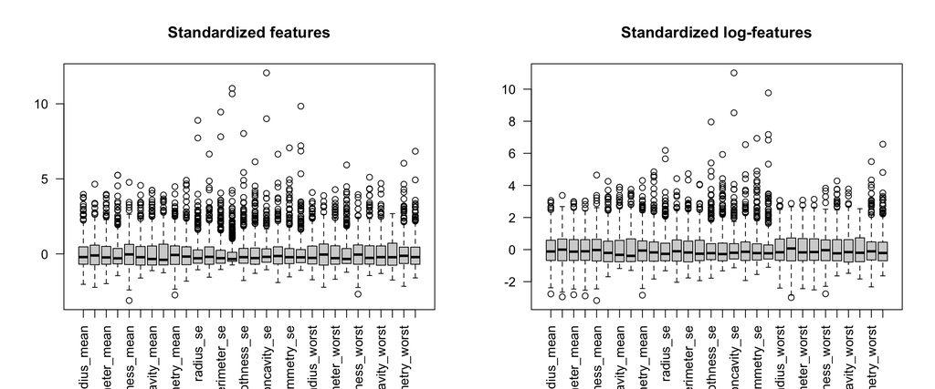

```r
# Visualizing the impact of log transformations on feature scale and skewness
par(mfrow = c(1, 2))

boxplot(
  scale(tumor[, -1]),
  main = "Standardized features",
  las = 2
)

boxplot(
  scale(log(tumor[, -1]+1)),
  main = "Standardized log-features",
  las = 2
)
```

```r
par(mfrow = c(1, 1))
```

The left plot shows the standardized original features. Several variables have many large positive outliers, with some standardized values above 10. This suggests that some predictors are strongly right-skewed.

The right plot shows the standardized logarithms of the features. After applying the logarithmic transformation, the distributions are more balanced around zero, and the most extreme positive values are reduced. The outliers are still present, but they are less extreme than in the original standardized features.

So, the logarithmic transformation reduces skewness and makes the feature distributions more comparable. This can be useful for methods such as SVMs, which are sensitive to the scale and distribution of the predictors.

**Question:** How do the boxplots change after applying the logarithmic transformation? Which version appears to have fewer extreme values?

2. Create a new dataset with log-transformed numeric features.

   We now repeat the model comparison using log-transformed predictors. This allows us to check whether reducing skewness in the predictors improves model performance.

   **Hint:** Use `mutate()` with `across(where(is.numeric), ...)` to apply the same transformation to all numeric predictors. We use `log(x + 1)` to avoid problems if any feature contains zero.

**Show Answer**

```r
# Safely applying log(x+1) to all numeric columns to prevent log(0) -Inf errors
ltumor <- tumor %>%
  mutate(across(where(is.numeric), ~ log(.x + 1))) %>%
  as.data.frame()

ltumor$diagnosis <- as.factor(ltumor$diagnosis)

# Training and test sets for the log-transformed data
ltumor_train <- ltumor[train, ]
ltumor_test  <- ltumor[-train, ]
```

3. Train the same models using the log-transformed features.

   Train a pruned tree, bagging model, random forest, XGBoost model, radial SVM, and linear SVM using the log-transformed training set.

   **Hint:** Use the same modelling functions as before, but replace `tumor` with `ltumor`. For XGBoost, create new objects such as `lx`, `ly`, and `ldtrain` so that we do not overwrite the objects used for the original features.

**Show Answer**

```r
## Pruned tree
ltumor_tree <- tree(
  diagnosis ~ .,
  data = ltumor_train
)

cv_ltumor <- cv.tree(ltumor_tree)

ltumor_prune <- prune.tree(
  ltumor_tree,
  best = cv_ltumor$size[which.min(cv_ltumor$dev)]
)

## Bagging
set.seed(1)
ltumor_bag <- randomForest(
  diagnosis ~ .,
  data = ltumor_train,
  importance = TRUE,
  mtry = 30,
  ntree = 250
)

## Random forest
set.seed(1)
ltumor_rf <- randomForest(
  diagnosis ~ .,
  data = ltumor_train,
  importance = TRUE,
  ntree = 250
)

## XGBoost preparation
ltumor_train$diagnosis <- as.factor(ltumor_train$diagnosis)

ly <- ifelse(ltumor_train$diagnosis == "M", 1, 0)

lx <- model.matrix(diagnosis ~ . - 1, data = ltumor_train)

ldtrain <- xgb.DMatrix(data = lx, label = ly)

## XGBoost tuning grid
lxgb_grid <- expand.grid(
  eta = c(0.3, 0.4),
  max_depth = c(1, 2, 3),
  gamma = 0,
  colsample_bytree = c(0.6, 0.8),
  min_child_weight = 1,
  subsample = c(0.5, 0.75, 1.0),
  nrounds = 100
)

# Create the same 5 folds for all XGBoost tuning combinations
set.seed(1)
lfolds <- createFolds(ltumor_train$diagnosis, k = 5, returnTrain = FALSE)

lcv_results <- list()

for (i in seq_len(nrow(lxgb_grid))) {

  lxgb_params <- list(
    objective = "binary:logistic",
    eval_metric = "error",
    eta = lxgb_grid$eta[i],
    max_depth = lxgb_grid$max_depth[i],
    gamma = lxgb_grid$gamma[i],
    colsample_bytree = lxgb_grid$colsample_bytree[i],
    min_child_weight = lxgb_grid$min_child_weight[i],
    subsample = lxgb_grid$subsample[i],
    seed = 1,
    verbosity = 0
  )

  lcv <- xgb.cv(
    params = lxgb_params,
    data = ldtrain,
    nrounds = lxgb_grid$nrounds[i],
    folds = lfolds,
    verbose = 0
  )

  leval_log <- lcv$evaluation_log
  lbest_idx <- which.min(leval_log$test_error_mean)

  lcv_results[[i]] <- data.frame(
    eta = lxgb_grid$eta[i],
    max_depth = lxgb_grid$max_depth[i],
    gamma = lxgb_grid$gamma[i],
    colsample_bytree = lxgb_grid$colsample_bytree[i],
    min_child_weight = lxgb_grid$min_child_weight[i],
    subsample = lxgb_grid$subsample[i],
    best_iteration = leval_log$iter[lbest_idx],
    error = leval_log$test_error_mean[lbest_idx],
    accuracy = 1 - leval_log$test_error_mean[lbest_idx]
  )
}

ltumor_xgb_tuning_results <- bind_rows(lcv_results)

ltumor_best_params_row <- ltumor_xgb_tuning_results %>%
  arrange(desc(accuracy)) %>%
  slice(1)

lfinal_params <- list(
  objective = "binary:logistic",
  eval_metric = "error",
  eta = ltumor_best_params_row$eta,
  max_depth = ltumor_best_params_row$max_depth,
  gamma = ltumor_best_params_row$gamma,
  colsample_bytree = ltumor_best_params_row$colsample_bytree,
  min_child_weight = ltumor_best_params_row$min_child_weight,
  subsample = ltumor_best_params_row$subsample,
  seed = 1,
  verbosity = 0
)

ltumor_xgb <- xgb.train(
  params = lfinal_params,
  data = ldtrain,
  nrounds = ltumor_best_params_row$best_iteration,
  verbose = 0
)

## Radial SVM
set.seed(1)
ltumor_svm_radial <- tune.svm(
  diagnosis ~ .,
  data = ltumor_train,
  kernel = "radial",
  cost = c(0.5, 1, 1.5),
  gamma = c(0.01, 0.05, 0.1),
  tunecontrol = tune.control(cross = 5)
)

## Linear SVM
set.seed(1)
ltumor_svm_linear <- tune.svm(
  diagnosis ~ .,
  data = ltumor_train,
  kernel = "linear",
  cost = c(0.5, 1, 1.5),
  tunecontrol = tune.control(cross = 5)
)
```

4. Save the test-set predictions for the models trained on the log-transformed features.

   **Hint:** Use `ltumor_test` as the test set. For XGBoost, create the test matrix using `model.matrix()` and make sure it has the same columns as the training matrix `lx`.

**Show Answer**

```r
# Pruned tree predictions
prune_l <- predict(
  ltumor_prune,
  newdata = ltumor_test,
  type = "class"
)

# Bagging predictions
bag_l <- predict(
  ltumor_bag,
  newdata = ltumor_test
)

# Random forest predictions
rf_l <- predict(
  ltumor_rf,
  newdata = ltumor_test
)

# XGBoost predictions
ltest_x <- model.matrix(diagnosis ~ . - 1, data = ltumor_test)
ltest_x <- ltest_x[, colnames(lx), drop = FALSE]

boost_prob_l <- predict(ltumor_xgb, ltest_x)

boost_l <- ifelse(
  boost_prob_l > 0.5,
  "M",
  "B"
)

boost_l <- factor(boost_l, levels = levels(ltumor_train$diagnosis))

# SVM predictions
svm_radial_l <- predict(
  ltumor_svm_radial$best.model,
  newdata = ltumor_test
)

svm_linear_l <- predict(
  ltumor_svm_linear$best.model,
  newdata = ltumor_test
)
```

5. Compare the performance of the models trained on the log-transformed features.

   Display the confusion matrices and calculate the number of misclassified observations and test accuracy for each model.

   **Hint:** Use `table()` to create confusion matrices. Use `sum(predicted != observed)` to count misclassified observations and `mean(predicted == observed)` to calculate accuracy.

**Show Answer**

```r
# Function to create confusion matrices
cf <- function(obs, est) {
  table(
    observed = obs,
    predicted = est
  )
}

cat("Pruned tree, log-transformed features\n")
```

```
## Pruned tree, log-transformed features
```

```r
cf(ltumor_test$diagnosis, prune_l)
```

```
##         predicted
## observed  B  M
##        B 86  0
##        M 19 38
```

```r
cat("\nBagging, log-transformed features\n")
```

```
##
## Bagging, log-transformed features
```

```r
cf(ltumor_test$diagnosis, bag_l)
```

```
##         predicted
## observed  B  M
##        B 84  2
##        M  9 48
```

```r
cat("\nRandom forest, log-transformed features\n")
```

```
##
## Random forest, log-transformed features
```

```r
cf(ltumor_test$diagnosis, rf_l)
```

```
##         predicted
## observed  B  M
##        B 85  1
##        M  6 51
```

```r
cat("\nBoosting, log-transformed features\n")
```

```
##
## Boosting, log-transformed features
```

```r
cf(ltumor_test$diagnosis, boost_l)
```

```
##         predicted
## observed  B  M
##        B 85  1
##        M  4 53
```

```r
cat("\nSVM radial, log-transformed features\n")
```

```
##
## SVM radial, log-transformed features
```

```r
cf(ltumor_test$diagnosis, svm_radial_l)
```

```
##         predicted
## observed  B  M
##        B 85  1
##        M  3 54
```

```r
cat("\nSVM linear, log-transformed features\n")
```

```
##
## SVM linear, log-transformed features
```

```r
cf(ltumor_test$diagnosis, svm_linear_l)
```

```
##         predicted
## observed  B  M
##        B 84  2
##        M  2 55
```

```r
# True labels for the log-transformed test set
observed_l <- ltumor_test$diagnosis

# Test performance for log-transformed features
log_model_performance <- data.frame(
  model = c(
    "Pruned tree",
    "Bagging",
    "Random forest",
    "Boosting",
    "SVM radial",
    "SVM linear"
  ),
  features = "Log-transformed",
  misclassified = c(
    sum(prune_l != observed_l),
    sum(bag_l != observed_l),
    sum(rf_l != observed_l),
    sum(boost_l != observed_l),
    sum(svm_radial_l != observed_l),
    sum(svm_linear_l != observed_l)
  ),
  accuracy = c(
    mean(prune_l == observed_l),
    mean(bag_l == observed_l),
    mean(rf_l == observed_l),
    mean(boost_l == observed_l),
    mean(svm_radial_l == observed_l),
    mean(svm_linear_l == observed_l)
  )
)

log_model_performance
```

```
##           model        features misclassified  accuracy
## 1   Pruned tree Log-transformed            19 0.8671329
## 2       Bagging Log-transformed            11 0.9230769
## 3 Random forest Log-transformed             7 0.9510490
## 4      Boosting Log-transformed             5 0.9650350
## 5    SVM radial Log-transformed             4 0.9720280
## 6    SVM linear Log-transformed             4 0.9720280
```

The results show that the log-transformed features give different test-set performance across the models.

The **pruned tree** performs the worst, with 19 misclassified observations and an accuracy of about 0.867. Most of its errors are malignant tumors predicted as benign, which is an important type of error in this classification problem.

The best performance is obtained by the SVM models. Both the radial SVM and the linear SVM misclassify only 4 observations, giving a test accuracy of about 0.972.

For the radial SVM, there is 1 benign tumor predicted as malignant and 3 malignant tumors predicted as benign. For the linear SVM, there are 2 benign tumors predicted as malignant and 2 malignant tumors predicted as benign.

**Question:** Did the log transformation improve test-set performance? Which model has the fewest misclassified observations after the log transformation?

**Answer:** After the log transformation, the best-performing models are the **radial SVM** and the **linear SVM**, both with **4 misclassified observations** and a test accuracy of approximately **0.972**. Boosting is the best-performing tree-based method after the log transformation, with **5 misclassified observations** and a test accuracy of approximately **0.965**.

To decide whether the log transformation improved performance, we need to compare these results with the corresponding results from the models trained on the original features. So, if you still have time, you can do it right now. Otherwise, please do not forget to do that at home.

# Remark

## Inspecting tree-based model outputs

For the pruned decision tree, we can display the final tree structure. For ensemble methods such as bagging, random forest, and boosting, the model contains many trees, so it is more useful to inspect their predicted labels and variable importance.

**Optional question:** What do the tree-based models predict for the first few observations in the test set?

**Hint:** Use `head()` to display the first few predicted labels. The object `tumor_test$diagnosis` contains the true labels for the test set.

**Show Answer**

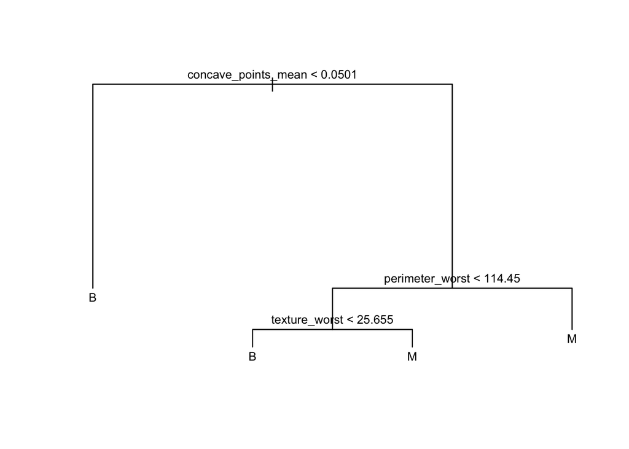

```r
# Display the final pruned tree
plot(tumor_prune)
text(tumor_prune, cex = 0.8)
```

```r
# Compare true and predicted labels for the first test observations
tree_predictions <- data.frame(
  observed = tumor_test$diagnosis,
  pruned_tree = prune,
  bagging = bag,
  random_forest = rf,
  boosting = boost
)

head(tree_predictions, 10)
```

```
##    observed pruned_tree bagging random_forest boosting
## 1         M           M       M             M        M
## 2         M           B       M             M        M
## 3         M           M       M             M        M
## 4         M           M       M             M        M
## 5         M           B       M             B        M
## 6         M           M       M             M        M
## 7         M           M       M             M        M
## 8         B           B       B             B        B
## 9         M           M       M             M        M
## 10        M           B       M             M        M
```

**Question:** Do the tree-based models make the same predictions for the first 10 test observations? Which observations, if any, are misclassified?

# Conclusion

In this practical, we applied several **supervised learning methods** to classify tumors as **benign** or **malignant** using the tumor dataset.

We trained and compared the following models:

- **Pruned decision tree**
- **Bagging**
- **Random forest**
- **Boosting (XGBoost)**
- **Support Vector Machines (linear and radial SVMs)**

The results show that a **single decision tree** can have weaker predictive performance than more advanced methods. Pruning helps control the complexity of the tree, but the tree-based ensemble methods generally performed better.

Ensemble methods such as **bagging**, **random forests**, and **boosting** combine many trees. This often improves predictive performance compared with a single tree. In this practical, **boosting** was the best-performing tree-based method.

The **SVM models** provided another powerful classification approach. We compared both a **linear kernel** and a **radial kernel**. This comparison showed that a more flexible nonlinear boundary is not always necessary; in this dataset, the linear SVM performed very well.

Finally, we evaluated all models on a **test set** using **confusion matrices**, the number of **misclassified observations**, and **test accuracy**. We also explored how **log-transforming the predictors** can influence model performance.

So, this practical illustrates how different machine learning methods can be applied to the same classification problem, and how their predictive performance may differ depending on the model complexity, tuning parameters, and data transformation.

End of lab